# Globalization from the Workers’ Side

Stephen Weymouth

Dean’s Professor

2026-11-02

# In 2004 a store clerk in Plano, Texas, took his résumé to a copy shop. Minutes later a typist in Chennai, India, was formatting it.

## Your IB Voice

How long does the advantage last?

Office Tiger came to Chennai, India, for its skilled graduates and low wages. By 2004 it was already opening an office in Colombo, Sri Lanka. What does that tell you about India’s advantage in services and how long it may last?

**10 minutes** · Individual · Notes permitted

## Competing explanations

Why did Wall Street banks send their work to Chennai, India?

College graduates in Chennai were paid a tenth of U.S. pay for the same work.

Chennai had thousands of English-speaking college graduates.

India’s government gave Office Tiger ten years without taxes.

After a scandal over biased stock research, U.S. banks moved some research to Chennai, away from Wall Street’s conflicts of interest.

Which of these advantages could India keep in the next decade?

# How do countries trade services?

## Services exports grew faster than goods exports

[figure not shown]

Instructor’s calculation from World Bank, [*World Development Indicators*](https://data.worldbank.org/indicator/BX.GSR.NFSV.CD), 2026: service exports and exports of goods and services, World, current U.S. dollars.

In 2026 a U.S. bank can have its software built in Bengaluru and its customer calls answered in Manila.

Services rose from 17 to 27 percent of world exports, so goods fell from 83 to 73 percent.

Internet helped overcome *proximity burden* (the need for producer and buyer to be in the same place)

*Trade in services* is selling work, such as software or advice, to a buyer in another country.

## Services cross borders in four ways

[figure not shown]

World Trade Organization, *World Trade Report 2019: The Future of Services Trade*, 2019: estimates for 2017.

Code written in Bengaluru and sent to a bank in New York is cross-border supply (Mode 1).

Students from India and China at U.S. universities buy U.S. education through consumption abroad (Mode 2).

Offshoring office work is mostly Mode 1, the mode the internet made cheap.

## India specializes in services, China in goods

[figure not shown]

Instructor’s calculation from World Bank, [*World Development Indicators*](https://data.worldbank.org/indicator/BX.GSR.NFSV.CD), 2026: exports of services and of goods and services, 2025.

India had English-speaking graduates, but less reliable power and ports than China.

*Revealed comparative advantage (RCA)* = country sector share ÷ world sector share.

# Why did the work go to Chennai?

## India became a large exporter of services

*Offshoring* is moving work to another country, to a firm’s own office or to a contractor such as Office Tiger.

Offshored software and IT support count as computer and telecom; offshored research and accounting count as other services.

Much of the growth after 2004 came from firms offshoring office work to India.

[figure not shown]

World Bank, [*World Development Indicators*](https://data.worldbank.org/indicator/BX.GSR.NFSV.CD?locations=IN), 2026: service exports and ICT service exports, India, current U.S. dollars.

## India is the seventh-largest exporter of services

[figure not shown]

World Bank, [*World Development Indicators*](https://data.worldbank.org/indicator/BX.GSR.NFSV.CD), 2026: service exports, 2024.

India and China are the only countries in the top ten that the World Bank does not class as high-income.

India sells almost as many services as goods: $375 billion against $447 billion.

India competes with the richest countries in selling work, not things.

## In Chennai the same research job paid a fifth or less

[figure not shown]

Boo, “The Best Job in Town,” *The New Yorker*, 2004.

Office Tiger’s first hires all had college degrees, and a third had graduate degrees.

Office Tiger still paid well above most incomes in the state.

*Wage arbitrage* is moving work to where workers of the same skill are paid less.

# “This is radical global change, and it is going to happen more and more.” Joe Sigelman, Office Tiger’s co-chief executive

# Who gained, and who lost?

## Harish taught new hires what Wall Street expected

[figure not shown]

Challengethelimits, [*A typical residential street in Triplicane, Chennai*](https://commons.wikimedia.org/wiki/File:A_typical_residential_street_in_the_neighbourhood_of_Triplicane,_Chennai..JPG), 2013 · Wikimedia Commons, CC BY-SA 3.0.

Harish failed school and left at sixteen, then took a computer-training course.

At Office Tiger he taught new hires the business tools and habits that New York clients expected.

His paycheck let his parents retire.

Offshoring brought Wall Street’s skills to Chennai’s workers, but tied their jobs to clients abroad.

## Inequality rose in India and in the United States

[figure not shown]

World Inequality Database via [Our World in Data](https://ourworldindata.org/grapher/income-share-top-10-before-tax-wid), 2026: income share of the richest 10 percent, before tax.

The richest tenth took a larger share of income in both countries.

In Chennai the new jobs went to English-speaking graduates, not to the stone crushers’ children.

When the gains go to a few, voters can turn against the governments that welcomed foreign firms (and those that don’t resist offshoring).

## The boom brought jobs to Chennai but not water

[figure not shown]

2018

[figure not shown]

2019

People came for the new jobs, and rents in Harish’s neighborhood doubled. In 2004 the main reservoir was dry; in 2019 it was dry again.

The new firms brought private wealth, but the city’s water, schools, and clinics did not improve.

Sentinel Hub, [*Chennai before the drought*](https://commons.wikimedia.org/wiki/File:Chennai_Before_the_Drought.png) and [*Chennai drought*](https://commons.wikimedia.org/wiki/File:Chennai_Drought.png), 2018 and 2019 · Wikimedia Commons, CC BY 2.0.

## No one agreed on how many U.S. jobs left

The Labor Department called the losses small, but it relied on firms to report jobs they sent abroad.

Wall Street firms had cut almost a fifth of their jobs in three years.

[figure not shown]

Boo, “The Best Job in Town,” *The New Yorker*, 2004, citing other analyses and a University of California, Berkeley study.

The losses in the United States were real, but no one could see them in one place.

## U.S. services imports grew, and so did exports

[figure not shown]

Instructor’s calculation from World Bank, [*World Development Indicators*](https://data.worldbank.org/indicator/TX.VAL.SERV.CD.WT?locations=US), 2026: U.S. commercial service exports and imports and their computer, communications, and other services shares.

In 2025 the U.S. surplus in all services, $328 billion, offset about a quarter of its $1,260 billion goods deficit.

U.S. firms sell software and professional services abroad and buy back-office work from countries such as India.

Who in the United States wins from services trade, and who loses?

## The election

In May 2004, while Office Tiger was hiring, Tamil Nadu’s voters gave all 40 of the state’s seats to the opposition. Why would a booming state vote against the government that welcomed the boom?

# How long does the advantage last?

## An Office Tiger founder later ran for Congress

In 2006 the founders sold Office Tiger for $250 million.

Randy Altschuler then ran for Congress on Long Island, losing in 2010 by 593 votes.

In 2012 his opponent’s ads asked, “Randy wouldn’t hire you, so why should we hire him?”

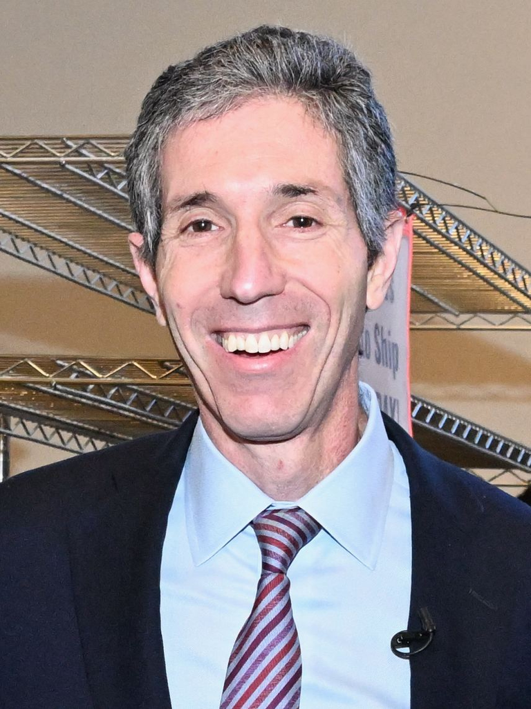

Maryland GovPics, [*Randy Altschuler*](https://commons.wikimedia.org/wiki/File:Randy_Altschuler.jpg), 2024 · Wikimedia Commons, CC BY 2.0.

## Software

Office Tiger’s typists formatted résumés, checked legal papers, and summarized company research. AI software can now do much of that work. Will firms keep sending this work to Chennai, or will they stop paying anyone to do it?

# Place the people on a grid

## Place the people on the grid

- Joe Sigelman, the co-founder
- Harish Kumar, the trainer
- A stone crusher’s child
- A software engineer in Seattle
- A back-office clerk in New Jersey

[figure not shown]

1. **Decide** if services trade since 2000 left each person better or worse off, and if each could move on to new work or would be stuck.
2. **Place** each in a square, with a reason.

**10 minutes** · Individual · Article permitted

## Report out

Which square holds most of the winners, and which holds most of the losers?

[figure not shown]

## Closing discussion

Office Tiger could move to Colombo or Manila. Harish could not leave his family, and the stone crushers could not leave the camps. What does that difference tell us about who gains from globalization?

## Takeaways

Who gains when work moves abroad?

Firms gained by moving work to where skilled workers are paid less.

In Chennai the jobs went to English-speaking graduates, while rents rose and water ran short.

Some U.S. workers lost tasks to India, yet the United States still sells more services than it buys.

An office moves more easily than a factory, so each worker’s gain lasted only as long as the wage gap.

Offshoring makes winners and losers in both countries, and the winners can usually move.